# Effects of Commuting on GoBike Use

# Investigation Overview

My hypothesis from the outset is that the Go Bikes are used for commuting to and from work. To investigate this I focused on three categories: the day of the week, the hour of the day, and the distance traveled. If bikes are used for commuting I will expect to see increased use on weekdays around 8am and 5pm.

# Dataset Overview

The dataset is for Ford GoBike usage in San Fancisco over the month of February, 2019. There are around 183,000 entries in the dataset. Each entry is a single ride that includes start/end time, duration, bike ID, and start/end points. As well as general user information: birth year, gender, subscriber status, and bike share for all status. The only cleaning I did to the data was changing the start/end time from a string to datetime.

# Distributrion of Bike use Over the month

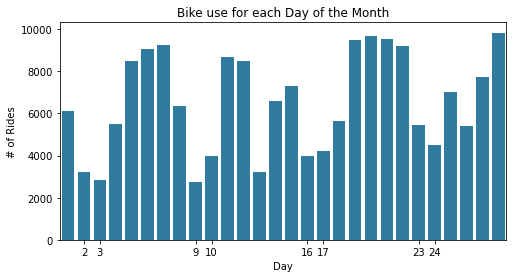

```python
plt.figure(figsize=(8, 4))
ticks = [1, 2, 8, 9, 15, 16, 22, 23]
labels = [i + 1 for i in ticks]
a = sb.countplot(x=go['start_time'].dt.day, color='#1e81b0')
plt.xticks(ticks, labels)
plt.xlabel('Day')
plt.ylabel('# of Rides')
plt.title('Bike use for each Day of the Month');
```

# Distribution of Bike use by Week Day

The number of rides occuring each day is much higher on weekdays than weekends. Saturdays and Sundays saw around 15,000 rides each, while each weekday saw closer to 30,000 rides. It also seems that the consistancy of Thursdays resulted in it beng the most popular day.

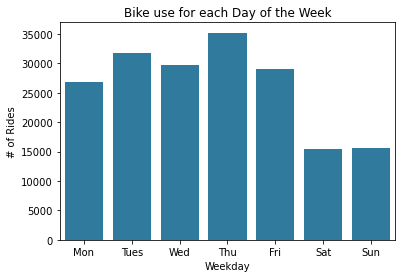

```python
ticks = [0, 1, 2, 3, 4, 5, 6]
labels = ['Mon', 'Tues', 'Wed', 'Thu', 'Fri', 'Sat', 'Sun']
ax = sb.countplot(data=go, x='weekday', color='#1e81b0')
plt.xticks(ticks, labels)
plt.xlabel('Weekday')
plt.ylabel('# of Rides')
plt.title('Bike use for each Day of the Week');
```

# Distribution of Bike use by Hour of the Day.

This bar chart clearly shows the bimodal distribution of bike use. Two massive spikes right at peak commuting hours add more support to my hypothesis that GoBikes are used for commuting. The correlation between commuting and bike use may only be chance. If that is the case, then the bimodal distribution of rides would be consistent every day of the week.

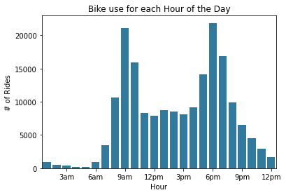

```python
ticks = [2, 5, 8, 11, 14, 17, 20, 23]
labels = ['3am', '6am', '9am', '12pm', '3pm', '6pm', '9pm', '12pm']
sb.countplot(data=go, x='hour', color='#1e81b0')
plt.xticks(ticks, labels)
plt.xlabel('Hour')
plt.ylabel('# of Rides')
plt.title('Bike use for each Hour of the Day');
```

# Bike use by Hour and Day

The violin plot shows the distribution of rides by hour for each day. It is important to point out that the plots are relative to their sample size. There are roughly 20,000 fewer data points for Saturday and Sunday than for Thursday. The bimodal distribution seen in the last plot is consistant through each day of the week, but weekends have a unimodal distribution centered on 3pm.

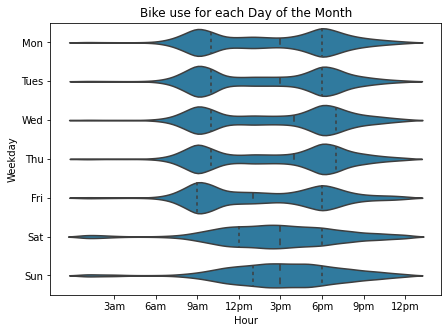

```python
plt.figure(figsize = [7,5])

ticks = [0, 1, 2, 3, 4, 5, 6]
labels = ['Mon', 'Tues', 'Wed', 'Thu', 'Fri', 'Sat', 'Sun']
xticks = [2, 5, 8, 11, 14, 17, 20, 23]
xlabels = ['3am', '6am', '9am', '12pm', '3pm', '6pm', '9pm', '12pm']
sb.violinplot(data=go, y='weekday', x='hour', color='#1e81b0', inner='quartile', orient='h')
plt.yticks(ticks, labels)
plt.xticks(xticks, xlabels)
plt.xlabel('Hour')
plt.ylabel('Weekday')
plt.title('Bike use for each Day of the Month');
```

# Average Distance Traveled on Weekends vs. Weekdays

When the average distance is plotted by the hour we once again see peaks at commuting times. In this case it is an increse in the average distance of each bike ride. This is not seen on weekends. Instead, the average distance remains much more consistant over the day. The average distance for all trips is 1.7km. The peak during the week is around 2km which is a 0.3km, or 15%, increase per ride.

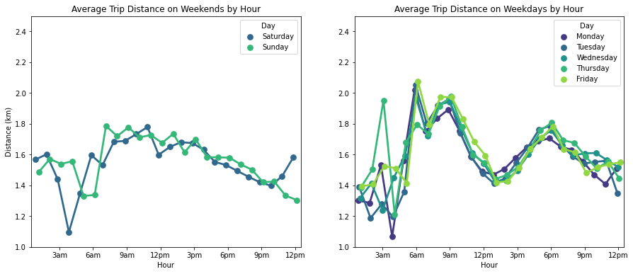

```python
plt.figure(figsize=[15, 6])

plt.subplot(1,2,1)
xticks = [2, 5, 8, 11, 14, 17, 20, 23]
xlabels = ['3am', '6am', '9am', '12pm', '3pm', '6pm', '9pm', '12pm']
g = sb.pointplot(data=weekend_df, x='hour', y='distance_km', hue='weekday', dodge=0.3, join=True, ci=False, palette='viridis')
plt.ylim(bottom=1.0, top=2.5)
plt.xticks(xticks, xlabels)
plt.xlabel('Hour')
plt.ylabel('Distance (km)')
plt.title('Average Trip Distance on Weekends by Hour')
labels = ['Saturday', 'Sunday']
h, l = g.get_legend_handles_labels()
g.legend(h, labels, title='Day');


plt.subplot(1,2,2)
xticks = [2, 5, 8, 11, 14, 17, 20, 23]
xlabels = ['3am', '6am', '9am', '12pm', '3pm', '6pm', '9pm', '12pm']
g = sb.pointplot(data=weekday_df, x='hour', y='distance_km', hue='weekday', dodge=0.3, join=True, ci=False, palette='viridis')
plt.ylim(bottom=1.0, top=2.5)
plt.xticks(xticks, xlabels)
plt.xlabel('Hour')
plt.ylabel('')
plt.title('Average Trip Distance on Weekdays by Hour')
labels = ['Monday', 'Tuesday', 'Wednesday', 'Thursday', 'Friday']
h, l = g.get_legend_handles_labels()
g.legend(h, labels, title='Day');
```

# Average and Total Distance Traveled by each Bike

There seems to be an upward trend in total distance ridden as bike number increases without an effect of the average distance ridden, with the exception of bikes numbered 4500 to 5500. If those are ignored, there is a logrithmic trend across the plot. Users prefer higher numbered bikes. If bikes are numbered as they enter the fleet that would mean users gravitate toward newer bikes. The group of bikes from 4500 to 5500 should follow the same trend if all bikes are the same. After further investigation I found that none of these bikes were located in San Jose, and were used more heavily in the UC Berkeley area.

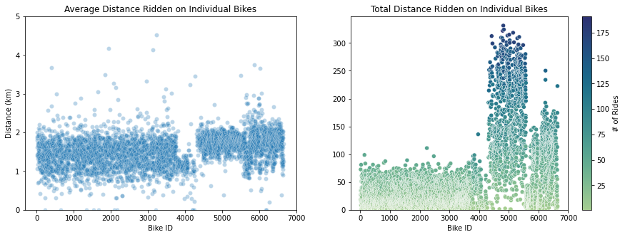

```python
plt.figure(figsize=[15, 5])

plt.subplot(1, 2, 1)
ticks = [0, 1000, 2000, 3000, 4000, 5000, 6000, 7000]
sb.scatterplot(data=by_bike, x='bike_id', y='distance_km', alpha=0.3)
plt.ylim(bottom=0, top=5)
plt.xticks(ticks)
plt.xlabel('Bike ID')
plt.ylabel('Distance (km)')
plt.title('Average Distance Ridden on Individual Bikes');

plt.subplot(1, 2, 2)
ticks = [0, 1000, 2000, 3000, 4000, 5000, 6000, 7000]
g = sb.scatterplot(data=bike_sum, x='bike_id', y='distance_km', hue='# of Rides', palette=sb.color_palette("crest", as_cmap=True))
sb.color_palette('mako', as_cmap=True)
plt.ylim(bottom=0)
plt.xlabel('Bike ID')
plt.ylabel('')
plt.title('Total Distance Ridden on Individual Bikes')
plt.xticks(ticks)
norm = plt.Normalize(bike_sum['# of Rides'].min(), bike_sum['# of Rides'].max())
sm = plt.cm.ScalarMappable(cmap='crest', norm=norm)
sm.set_array([])
g.get_legend().remove()
bar = g.figure.colorbar(sm)
bar.set_label('# of Rides');
```